# Human Activity Recognition based on machine learning

### Exploritory analyis

First the data is training and testing set is dowloaded from the server:

```r
library(caret)
```

```r
trainingdata_url <- "https://d396qusza40orc.cloudfront.net/predmachlearn/pml-training.csv"
dest_training <- "./pml-training.csv"
download.file(trainingdata_url,dest_training)
train_data <- read.csv(dest_training)

testingdata_url <- "https://d396qusza40orc.cloudfront.net/predmachlearn/pml-testing.csv"
dest_testing <- "./pml-testing.csv"
download.file(testingdata_url,dest_testing)
test_data <- read.csv(dest_testing)
```

The data consist of 160 varibales, most of which are measurement from motion sensors (accelerometers, gyros, magnets) To get a first grasp of the data the time series of three sensor are plotted:

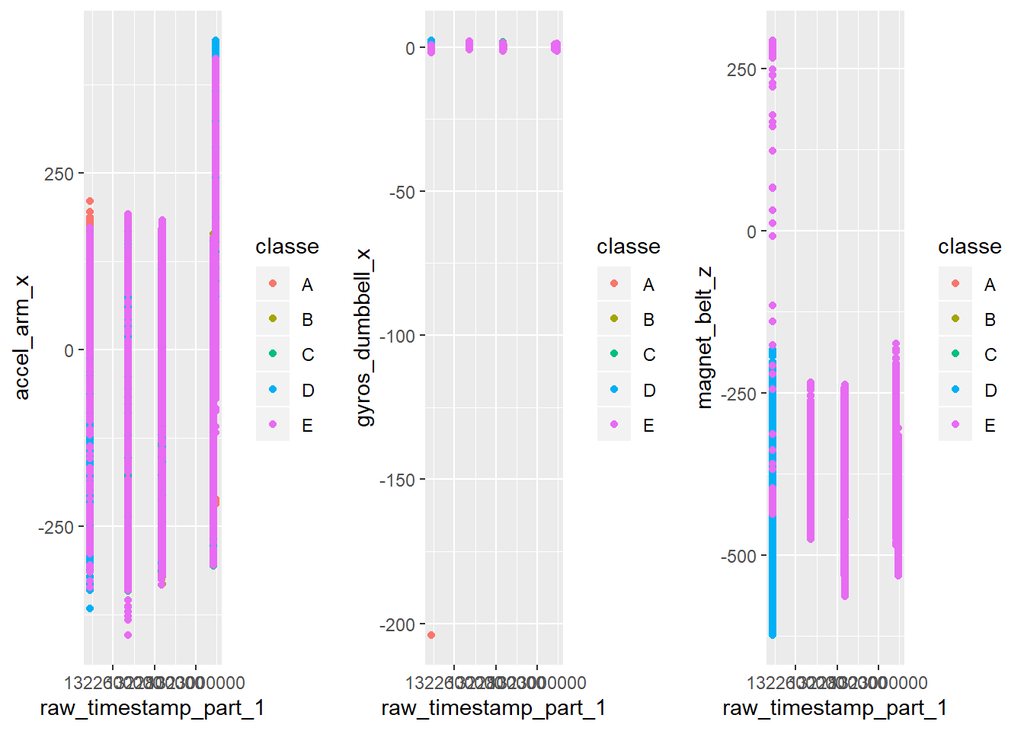

```r
library(ggplot2)
library(ggpubr)
f1 <- ggplot(train_data,aes(x = raw_timestamp_part_1,y=accel_arm_x,color=classe)) + geom_point()
f2 <- ggplot(train_data,aes(x = raw_timestamp_part_1,y=gyros_dumbbell_x,color=classe)) + geom_point()
f3 <- ggplot(train_data,aes(x = raw_timestamp_part_1,y=magnet_belt_z,color=classe)) + geom_point()
ggarrange(f1, f2,f3, ncol=3, nrow=1)
```

### cross validation

To estimate the out of sample error we split the data set into a training and a test set. A clean split can be used since there are enough observation in the data-set, so no K-folds or similar approach is required:

```r
train_index <- createDataPartition(train_data$classe,p=0.7,list=FALSE)
train <- train_data[train_index,]
test <- train_data[-train_index,]
```

### model selection

Before training the model the variables with little information are removed:

```r
na_count <-sapply(train_data, function(y) sum(length(which(is.na(y) | y==""))))
train <- train[,!na_count > 19000]
test <- test[,!na_count > 19000]
train <- train[-c(1:7)]
test <- test[-c(1:7)]
```

This brings the number of variables down from 160 to 53 variables. To bring down the amount of variables even further a linear model is fitted to which variables contribute the most to the model. All variables with a coeffient < 0.05 are removed from the data set:

```r
lm_fit <- lm(classe~.,data=train)
var_small_coef <- abs(lm_fit$coefficients)>0.05
train <- train[c(var_small_coef[-1],TRUE)]
test <- test[c(var_small_coef[-1],TRUE)]
```

Ten variables remain, with these variabels two models are training, one using the random forest algorithm and one using regulare regression trees. It is expected that the random forrest algorithm will perform better:

```r
rf_fit <- train(classe~.,data=train,method="rf")
rpart_fit <- train(classe~.,data=train,method="rpart")
```

## Out of sample error

To determine the out of sample error rate. The created test is used. First the classe is predicted using our moddels and compared the real values by plotting the result in a confusionmatrix:

```r
rf_predict <- predict(rf_fit,newdata=test)
rpart_predict <- predict(rpart_fit,newdata=test)

library(forecast)
rf_matrix  <- confusionMatrix(rf_predict,test$classe)
rpart_matrix <- confusionMatrix(rpart_predict,test$classe)
rf_matrix
```

```
## Confusion Matrix and Statistics
##
##           Reference
## Prediction    A    B    C    D    E
##          A 1484   78  134   98   45
##          B   46  951   26   15   43
##          C   74   67  795   88   38
##          D   62   33   59  738   19
##          E    8   10   12   25  937
##
## Overall Statistics
##
##                Accuracy : 0.8335
##                  95% CI : (0.8237, 0.8429)
##     No Information Rate : 0.2845
##     P-Value [Acc > NIR] : < 2.2e-16
##
##                   Kappa : 0.7886
##
##  Mcnemar's Test P-Value : < 2.2e-16
##
## Statistics by Class:
##
##                      Class: A Class: B Class: C Class: D Class: E
## Sensitivity            0.8865   0.8349   0.7749   0.7656   0.8660
## Specificity            0.9157   0.9726   0.9451   0.9648   0.9885
## Pos Pred Value         0.8070   0.8797   0.7486   0.8101   0.9446
## Neg Pred Value         0.9530   0.9609   0.9521   0.9546   0.9704
## Prevalence             0.2845   0.1935   0.1743   0.1638   0.1839
## Detection Rate         0.2522   0.1616   0.1351   0.1254   0.1592
## Detection Prevalence   0.3125   0.1837   0.1805   0.1548   0.1686
## Balanced Accuracy      0.9011   0.9038   0.8600   0.8652   0.9273
```

```r
rpart_matrix
```

```
## Confusion Matrix and Statistics
##
##           Reference
## Prediction    A    B    C    D    E
##          A 1658  907  998  876  615
##          B   10  216   22   26  206
##          C    0    0    0    0    0
##          D    0    0    0    0    0
##          E    6   16    6   62  261
##
## Overall Statistics
##
##                Accuracy : 0.3628
##                  95% CI : (0.3505, 0.3752)
##     No Information Rate : 0.2845
##     P-Value [Acc > NIR] : < 2.2e-16
##
##                   Kappa : 0.1259
##
##  Mcnemar's Test P-Value : NA
##
## Statistics by Class:
##
##                      Class: A Class: B Class: C Class: D Class: E
## Sensitivity            0.9904  0.18964   0.0000   0.0000  0.24122
## Specificity            0.1935  0.94437   1.0000   1.0000  0.98126
## Pos Pred Value         0.3281  0.45000      NaN      NaN  0.74359
## Neg Pred Value         0.9807  0.82923   0.8257   0.8362  0.85164
## Prevalence             0.2845  0.19354   0.1743   0.1638  0.18386
## Detection Rate         0.2817  0.03670   0.0000   0.0000  0.04435
## Detection Prevalence   0.8588  0.08156   0.0000   0.0000  0.05964
## Balanced Accuracy      0.5920  0.56701   0.5000   0.5000  0.61124
```

### Apply model to test case

We can use the model to predict the ‘classe’ value of our testcase as follows:

```r
rf_predict_testcase <- predict(rf_fit,newdata=test_data)
rf_predict_testcase
```

```
##  [1] B A B A A E D B A A A C B A E E A B B B
## Levels: A B C D E
```